# Explore and Summarize Data Project

Miriam Wanjohi

October 10, 2018

## Introduction

> This exploratory data analysis project is based on the ’White wine quality, dataset.The dependent variable was the quality score (0-10) of the wine by wine experts based on 11 independent variables/characteristics.

#### Summary of the variables

```
##        X        fixed.acidity    volatile.acidity  citric.acid
##  Min.   :   1   Min.   : 3.800   Min.   :0.0800   Min.   :0.0000
##  1st Qu.:1225   1st Qu.: 6.300   1st Qu.:0.2100   1st Qu.:0.2700
##  Median :2450   Median : 6.800   Median :0.2600   Median :0.3200
##  Mean   :2450   Mean   : 6.855   Mean   :0.2782   Mean   :0.3342
##  3rd Qu.:3674   3rd Qu.: 7.300   3rd Qu.:0.3200   3rd Qu.:0.3900
##  Max.   :4898   Max.   :14.200   Max.   :1.1000   Max.   :1.6600
##  residual.sugar     chlorides       free.sulfur.dioxide
##  Min.   : 0.600   Min.   :0.00900   Min.   :  2.00
##  1st Qu.: 1.700   1st Qu.:0.03600   1st Qu.: 23.00
##  Median : 5.200   Median :0.04300   Median : 34.00
##  Mean   : 6.391   Mean   :0.04577   Mean   : 35.31
##  3rd Qu.: 9.900   3rd Qu.:0.05000   3rd Qu.: 46.00
##  Max.   :65.800   Max.   :0.34600   Max.   :289.00
##  total.sulfur.dioxide    density             pH          sulphates
##  Min.   :  9.0        Min.   :0.9871   Min.   :2.720   Min.   :0.2200
##  1st Qu.:108.0        1st Qu.:0.9917   1st Qu.:3.090   1st Qu.:0.4100
##  Median :134.0        Median :0.9937   Median :3.180   Median :0.4700
##  Mean   :138.4        Mean   :0.9940   Mean   :3.188   Mean   :0.4898
##  3rd Qu.:167.0        3rd Qu.:0.9961   3rd Qu.:3.280   3rd Qu.:0.5500
##  Max.   :440.0        Max.   :1.0390   Max.   :3.820   Max.   :1.0800
##     alcohol         quality
##  Min.   : 8.00   Min.   :3.000
##  1st Qu.: 9.50   1st Qu.:5.000
##  Median :10.40   Median :6.000
##  Mean   :10.51   Mean   :5.878
##  3rd Qu.:11.40   3rd Qu.:6.000
##  Max.   :14.20   Max.   :9.000
```

```
##  [1] "X"                    "fixed.acidity"        "volatile.acidity"
##  [4] "citric.acid"          "residual.sugar"       "chlorides"
##  [7] "free.sulfur.dioxide"  "total.sulfur.dioxide" "density"
## [10] "pH"                   "sulphates"            "alcohol"
## [13] "quality"
```

#### Datatypes

```
## 'data.frame':    4898 obs. of  13 variables:
##  $ X                   : int  1 2 3 4 5 6 7 8 9 10 ...
##  $ fixed.acidity       : num  7 6.3 8.1 7.2 7.2 8.1 6.2 7 6.3 8.1 ...
##  $ volatile.acidity    : num  0.27 0.3 0.28 0.23 0.23 0.28 0.32 0.27 0.3 0.22 ...
##  $ citric.acid         : num  0.36 0.34 0.4 0.32 0.32 0.4 0.16 0.36 0.34 0.43 ...
##  $ residual.sugar      : num  20.7 1.6 6.9 8.5 8.5 6.9 7 20.7 1.6 1.5 ...
##  $ chlorides           : num  0.045 0.049 0.05 0.058 0.058 0.05 0.045 0.045 0.049 0.044 ...
##  $ free.sulfur.dioxide : num  45 14 30 47 47 30 30 45 14 28 ...
##  $ total.sulfur.dioxide: num  170 132 97 186 186 97 136 170 132 129 ...
##  $ density             : num  1.001 0.994 0.995 0.996 0.996 ...
##  $ pH                  : num  3 3.3 3.26 3.19 3.19 3.26 3.18 3 3.3 3.22 ...
##  $ sulphates           : num  0.45 0.49 0.44 0.4 0.4 0.44 0.47 0.45 0.49 0.45 ...
##  $ alcohol             : num  8.8 9.5 10.1 9.9 9.9 10.1 9.6 8.8 9.5 11 ...
##  $ quality             : int  6 6 6 6 6 6 6 6 6 6 ...
```

## Univariate plots

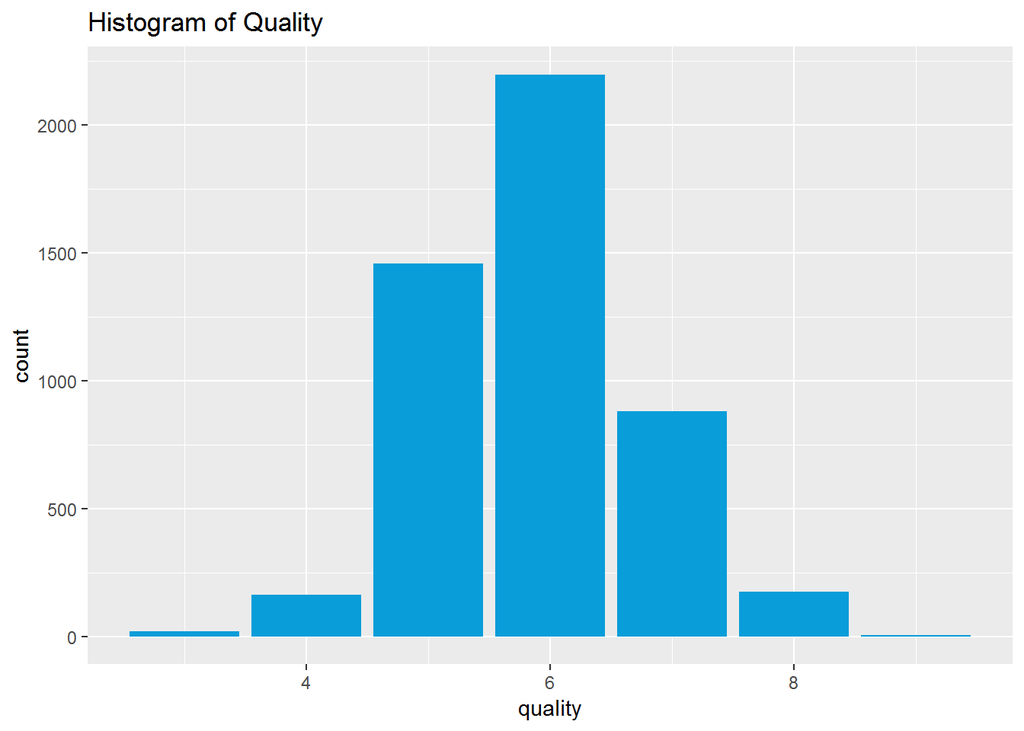

```
##    Min. 1st Qu.  Median    Mean 3rd Qu.    Max.
##   3.000   5.000   6.000   5.878   6.000   9.000
```

> The minimum quality rating was 3.0 while the maximum rating was 9.0. The mean score was 5.88 which was very close to the median score of 6.0 with the plot appearing to have a normal distribution. It seems like most wines got a score of 6, which is certainly an interesting score.

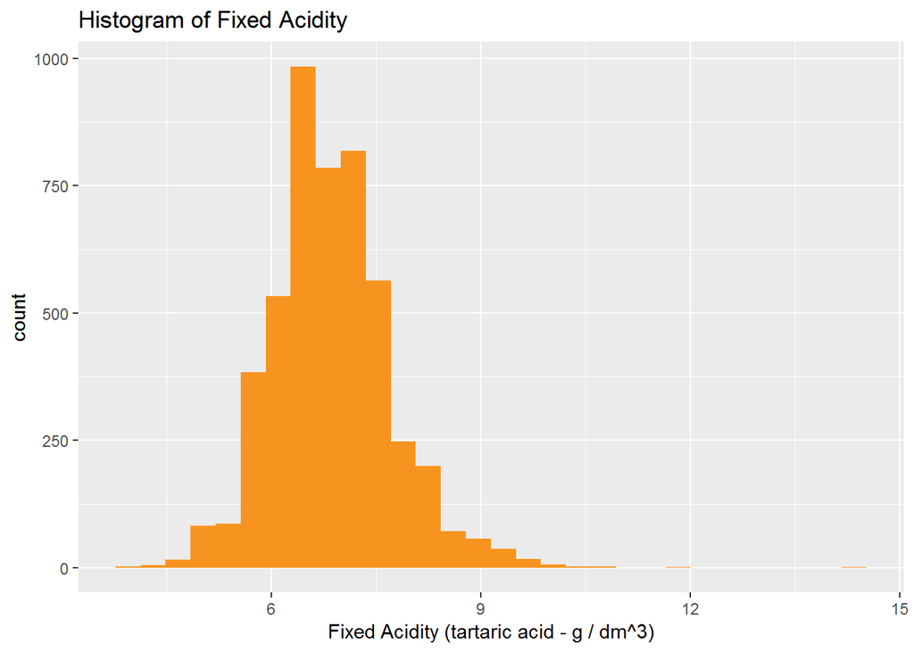

```
##    Min. 1st Qu.  Median    Mean 3rd Qu.    Max.
##   3.800   6.300   6.800   6.855   7.300  14.200
```

> The plot of count vs fixed acidity was almost normally distributed with the minimum value at 3.8, max value at 14.20 and the median at 6.8.

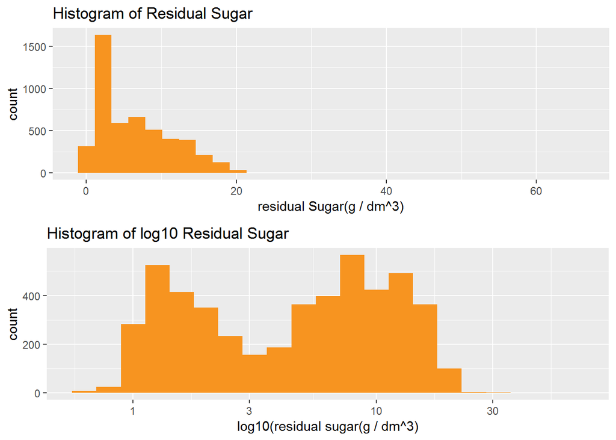

```
##    Min. 1st Qu.  Median    Mean 3rd Qu.    Max.
##   0.600   1.700   5.200   6.391   9.900  65.800
```

> The plot of residual sugar vs count was skewed to the right with a very long tail given the fact that the max point was 65.8 while the mean was ony at 6.39. I therefore did a log transformation to achieve a bimodal distribution with peaks at 1.5 g/dm^3 and ~9g/dm^3. The plot makes practical sense given the rarity of wines with less that 1 g/l and more than 45 g/liter.(1)

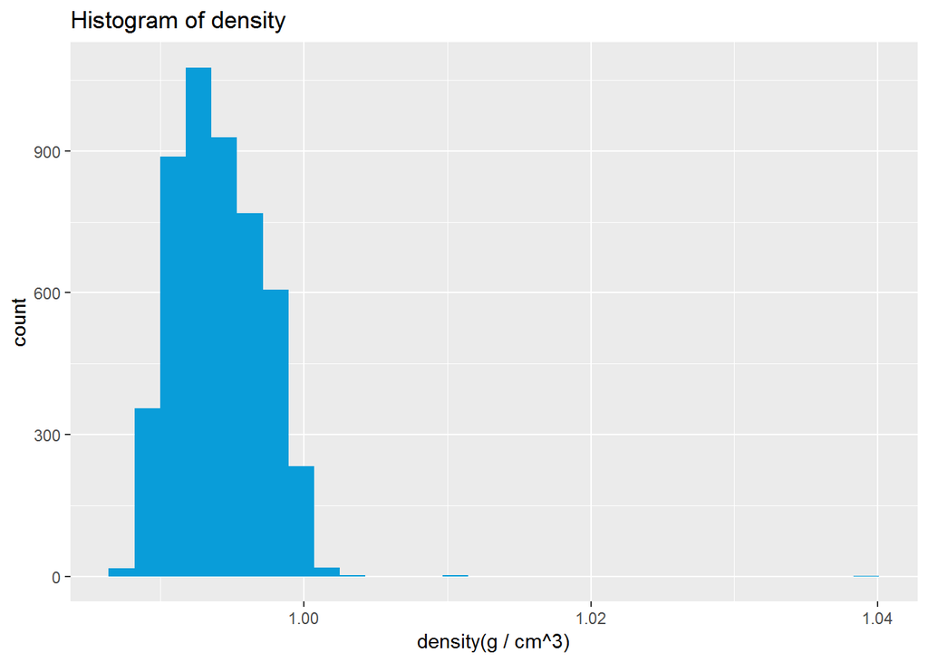

```
##    Min. 1st Qu.  Median    Mean 3rd Qu.    Max.
##  0.9871  0.9917  0.9937  0.9940  0.9961  1.0390
```

> According to the text (2) the density of most wines should be close to the density of water which is 1g/cm^3. In the data, the minimum wine density was 0.98 and the maximum at 1.04.The data is slighlty skewed to the right but most values are close to 1.

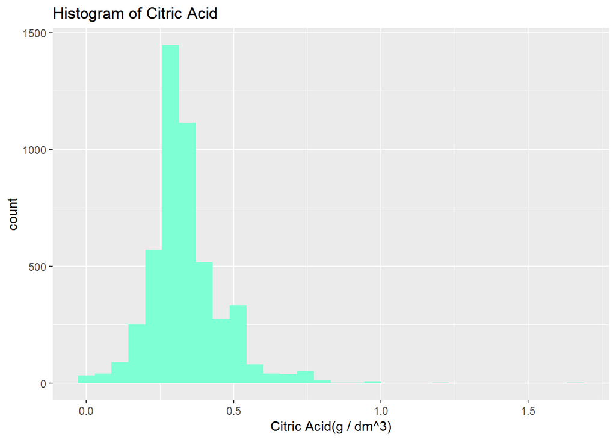

```
##    Min. 1st Qu.  Median    Mean 3rd Qu.    Max.
##  0.0000  0.2700  0.3200  0.3342  0.3900  1.6600
```

> Citric Acid variable has almost a normal distribution as well. It will be interesting to compare citric acid and quality score to determine the amount of citric acid that yields a high quality score.

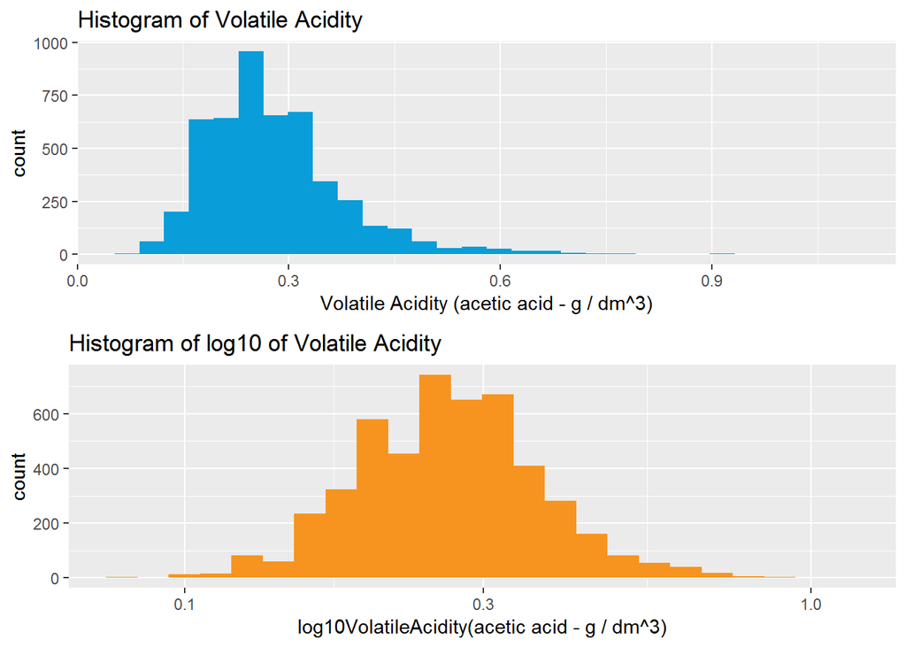

```
##    Min. 1st Qu.  Median    Mean 3rd Qu.    Max.
##  0.0800  0.2100  0.2600  0.2782  0.3200  1.1000
```

> The plot of volatile acidity vs count had a very long right tail. I therefore did a log tranformation to yield an almost normal distribution.

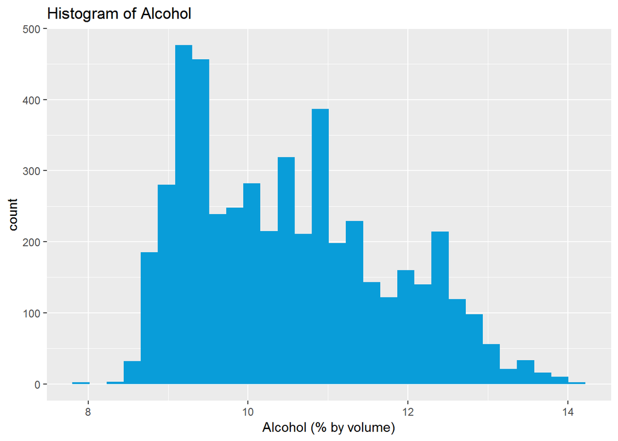

```
##    Min. 1st Qu.  Median    Mean 3rd Qu.    Max.
##    8.00    9.50   10.40   10.51   11.40   14.20
```

> Although the plot for alcohol is not exactly a normal distribution, I chose to use as is without any transformation. The wine with the least alcohol per volume was at 8% and the maximum alcohol per volume was 14.2%. Most wines in the dataset had about 10.4% alcohol per volume.

[output not shown]

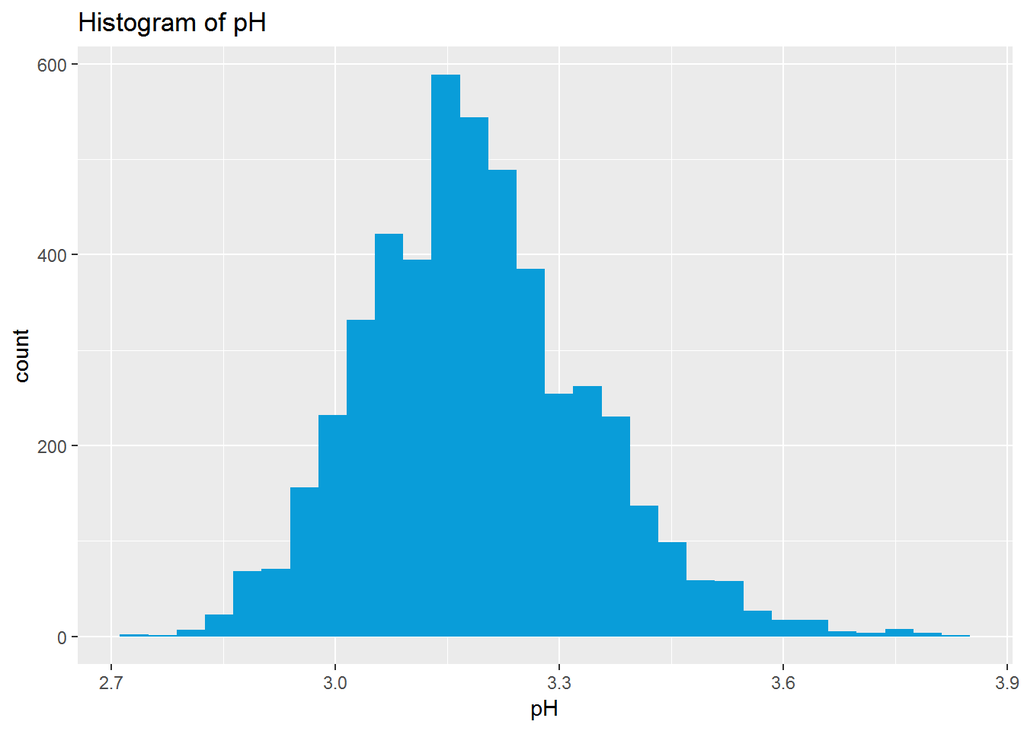

> Most wines are between 3-4 on the pH scale which makes sense due to the presence of acetic and citric acid.

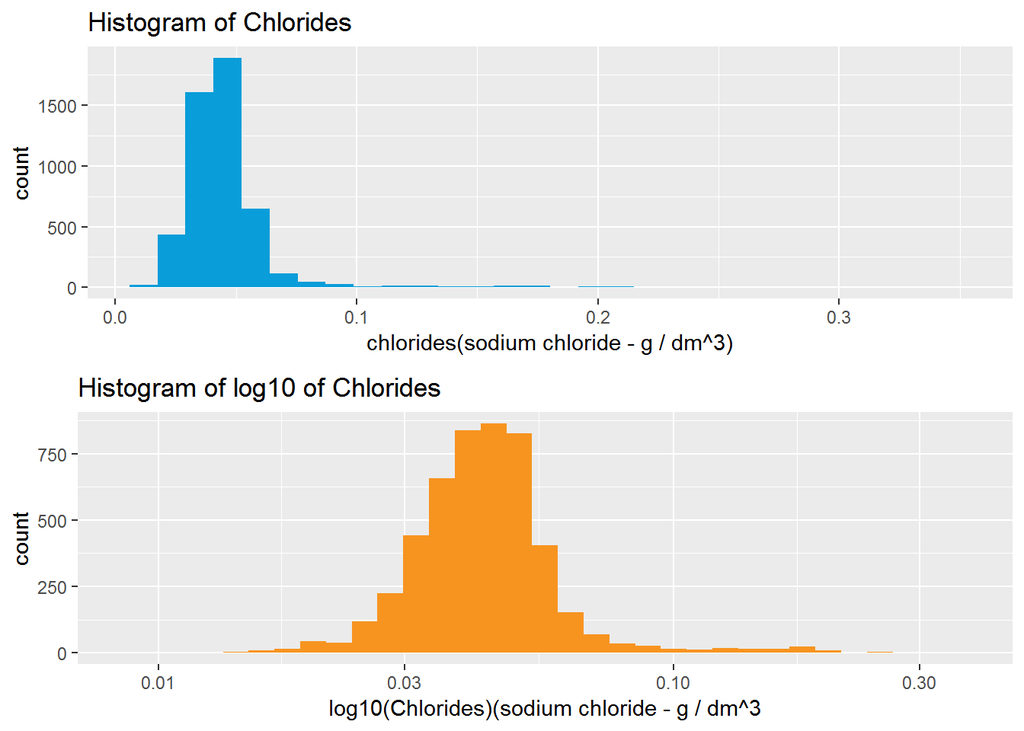

```
##    Min. 1st Qu.  Median    Mean 3rd Qu.    Max.
## 0.00900 0.03600 0.04300 0.04577 0.05000 0.34600
```

> I also did a log transformation of the chloride variable as it was highly skewed to the right with a long tail. the transformed variable had almost a normal distribution. The maximum value of salt seems to be really high and can almost be classified as an outlier given that the amount of salt in most wines is 0.043 compared to the maximum of 0.34. it would be interesting to determine how the amount of salt in wines affects other aspects of the wine such as total and volatile acidity.

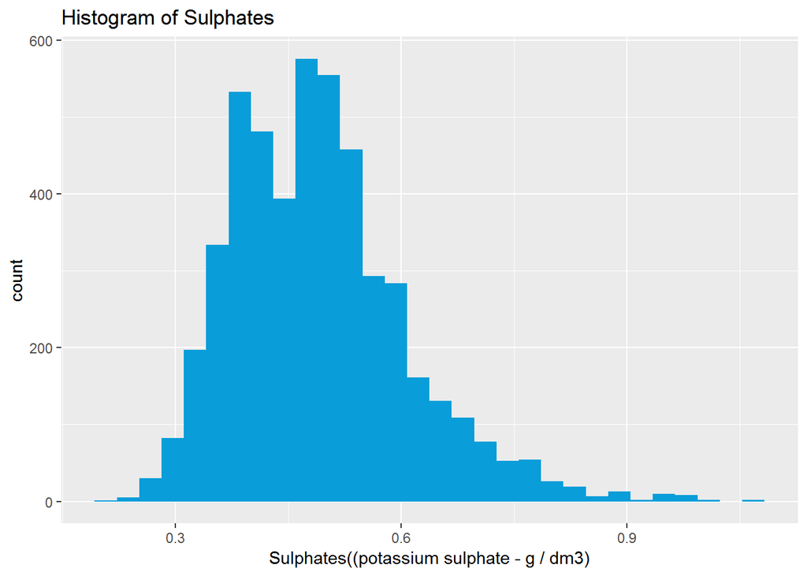

```
##    Min. 1st Qu.  Median    Mean 3rd Qu.    Max.
##  0.2200  0.4100  0.4700  0.4898  0.5500  1.0800
```

> The sulphates plot has a short tail to the right but does not really need any transformation. Given that sulphates contributes to sulfur dioxide concentrations in wine, we can look at the correlation between this variable and the free and total sulfur dioxide varibles and their effect on the wine quality rating.

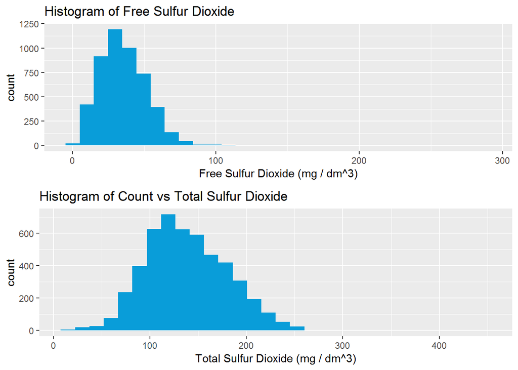

```
##    Min. 1st Qu.  Median    Mean 3rd Qu.    Max.
##    2.00   23.00   34.00   35.31   46.00  289.00
```

```
##    Min. 1st Qu.  Median    Mean 3rd Qu.    Max.
##     9.0   108.0   134.0   138.4   167.0   440.0
```

> Free and total sulfur dioxide plots are both normally distributed. Based on previous research, countries regulate the amount of Sulfur dioxide in foods and in the United States, Sulfur dioxide concentrations allowed in wine are set at 350mg/dm^3 (1). So it is quite intriguing as to why some of these wines have such high concentrations of Sulfur dioxide with the maximum value recorded in the dataset at 440mg/dm^3.

#### To create a new variable (quality_groups)

```
## < table of extent 0 >
```

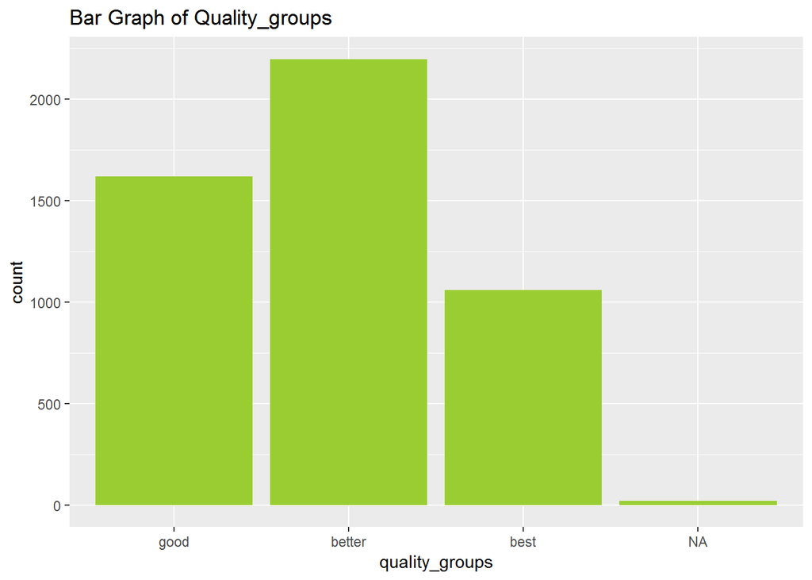

# Univariate Analysis

## What is the structure of your dataset?

> The dataset contains 4898 observations and 13 variables. The data was collected from white wine quality ratings by wine experts based on the several tests including pH, acidity, residual sugars, total sulfur dioxide levels among others(2).

> The 11 variables include: 1 - fixed acidity (tartaric acid - g/dm^3) 2 - volatile acidity (acetic acid - g/dm^3) 3 - citric acid (g/dm^3) 4 - residual sugar (g/dm^3) 5 - chlorides (sodium chloride - g/dm^3 6 - free sulfur dioxide (mg/dm^3) 7 - total sulfur dioxide (mg/dm^3) 8 - density (g/cm^3) 9 - pH 10 - sulphates (potassium sulphate - g/dm3) 11 - alcohol (% by volume) Output variable (based on sensory data): 12 - quality (score between 0 and 10)

> Some of the observations we have made from the univariate analyses include: 1. most wines in the dataset have an average rating (5-6 in the rating score) 2. There are wines that have almost unusual chloride and total sulfur dioxide levels 3. Almost all the wines have pH levels between 3-4 4. 75% of wines in the dataset had residual sugars less than 9.9 g/dm^3 while the wine with the highest residual sugar had a whooping 65.8g/dm^3

## What is/are the main features of interest in your dataset?

> Using this data, I am interested in answering the following question; 1. Does the amount of residual sugar affect the quality score? in other words, are sweeter wines rated higher than non-sweeter ones? 2. Does the amount of alcohol in wine increase the quality rating? 3. What is the effect of sulfates and sulfur compounds (total and free sulfur dioxide) affect the quality score? 4. what characteristics in combination can be used to better predict whether white wine receives a good, average or best score?

## Of the features you investigated, were there any unusual distributions? Did you perform any operations on the data to tidy, adjust, or change the form of the data? If so, why did you do this?

# Bivariate Plots

#### Scatterplot Matrices

```
## [1] "fixed.acidity"        "residual.sugar"       "free.sulfur.dioxide"
## [4] "total.sulfur.dioxide" "density"              "pH"
## [7] "alcohol"              "quality"
```

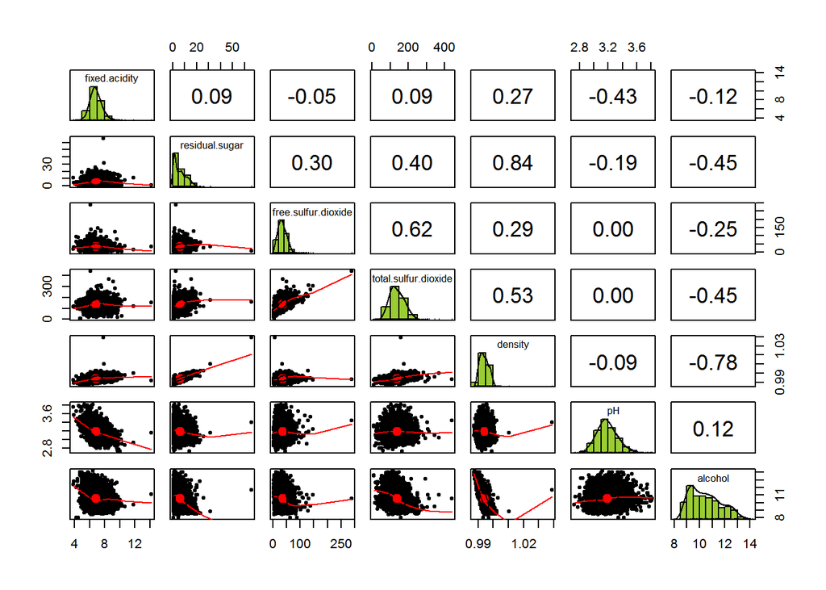

#### Boxplots of Variables of interest vs Quality

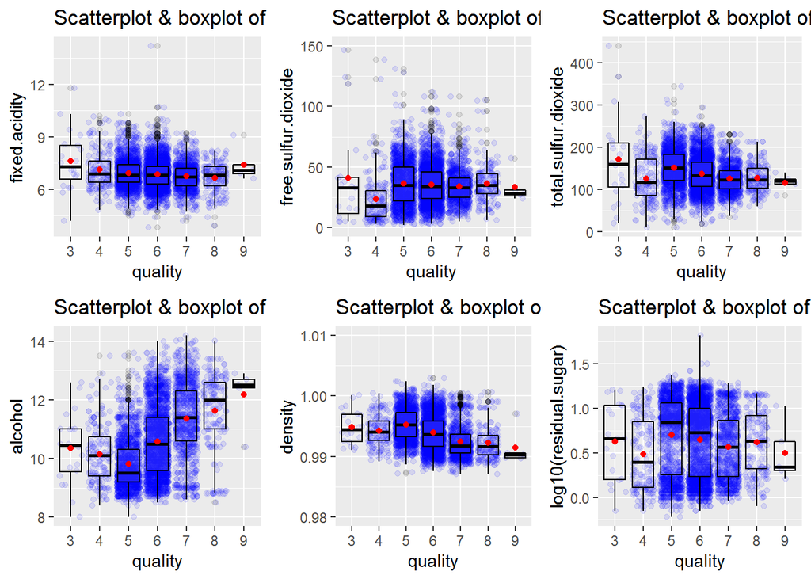

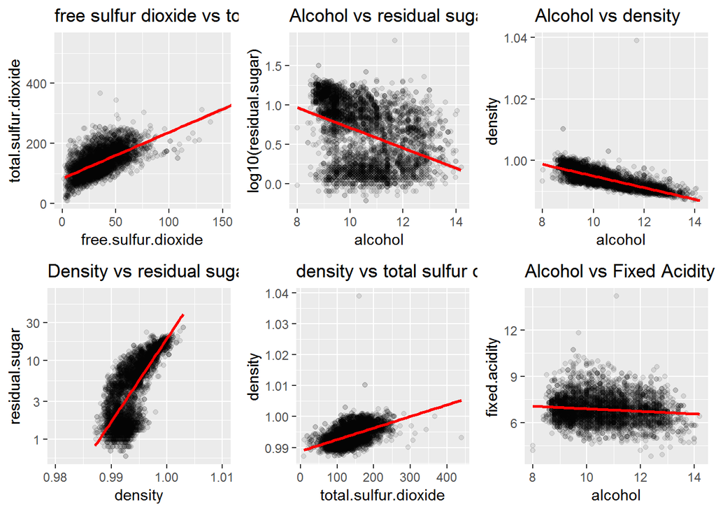

##### Corr.coeff(free.sulfur.dioxide & Total Sulfur dioxide)

```
##
##  Pearson's product-moment correlation
##
## data:  free.sulfur.dioxide and total.sulfur.dioxide
## t = 54.645, df = 4896, p-value < 2.2e-16
## alternative hypothesis: true correlation is not equal to 0
## 95 percent confidence interval:
##  0.5977994 0.6326026
## sample estimates:
##      cor
## 0.615501
```

##### Corr.coeff(Alcohol & residual sugar)

```
##
##  Pearson's product-moment correlation
##
## data:  residual.sugar and alcohol
## t = -35.321, df = 4896, p-value < 2.2e-16
## alternative hypothesis: true correlation is not equal to 0
## 95 percent confidence interval:
##  -0.4726723 -0.4280267
## sample estimates:
##        cor
## -0.4506312
```

##### Corr.coeff(alcohol & density)

```
##
##  Pearson's product-moment correlation
##
## data:  density and alcohol
## t = -87.255, df = 4896, p-value < 2.2e-16
## alternative hypothesis: true correlation is not equal to 0
## 95 percent confidence interval:
##  -0.7908646 -0.7689315
## sample estimates:
##        cor
## -0.7801376
```

##### Corr.coeff(density & residual Sugar)

```
##
##  Pearson's product-moment correlation
##
## data:  residual.sugar and density
## t = 107.87, df = 4896, p-value < 2.2e-16
## alternative hypothesis: true correlation is not equal to 0
## 95 percent confidence interval:
##  0.8304732 0.8470698
## sample estimates:
##       cor
## 0.8389665
```

##### Corr.coeff(density & total sulfur dioxide)

```
##
##  Pearson's product-moment correlation
##
## data:  density and total.sulfur.dioxide
## t = 43.719, df = 4896, p-value < 2.2e-16
## alternative hypothesis: true correlation is not equal to 0
## 95 percent confidence interval:
##  0.5094349 0.5497297
## sample estimates:
##       cor
## 0.5298813
```

##### Corr.coeff(Alcohol & Fixed Acidity)

```
##
##  Pearson's product-moment correlation
##
## data:  alcohol and fixed.acidity
## t = -8.5207, df = 4896, p-value < 2.2e-16
## alternative hypothesis: true correlation is not equal to 0
## 95 percent confidence interval:
##  -0.14838523 -0.09319016
## sample estimates:
##        cor
## -0.1208811
```

> The scatter plots above with a linear model show some variables that have either positive or negative correlations with the pearson r’s values corresponding to the individual plot.

# Bivariate Analysis

### How did the features of intested vary with other features in the dataset?

> For the bivariate analysis, I focused on the variables; alcohol, residual sugar, fixed acidity and density, free and total sulfur dioxide as independent variables. This was based on the higher positive and negative correlations between the variables. It seemed that the quality score rating was higher for wines with a high alcohol content, low density, low free and total sulfur dioxide. Also, wines with low fixed acidity content and less residual sugar scored higher on the quality rating. In the multivariate analysis, I will explore these variables further to determine the relationship between the outcome variable (quality) and a combination of the different characteristics.

### Did you observe any interesting relationships between the other features (not the main features of interest?)

### What was the strongest relationship you found?

> *There was a strong positive correlation between free sulfur dioxide and total sulfur dioxide with a corr. coeff of 0.61.
> - Strong negative correlation between density and alcohol with a corr. coeff of -0.78. the density of the wine decreased as the alcohol content increased.
> - Strong positive relationship between residual sugar and density with an r of 0.84
> - There was also a negative correlation between residual sugar and alcohol. Although the corr.coeff was -0.45 which is somehow a weak correlation, we can conclude that wines with higher alcohol percent per volume tend to be less sweeter than wines with less alcohol percent per volume.

# Multivariate Plots Section

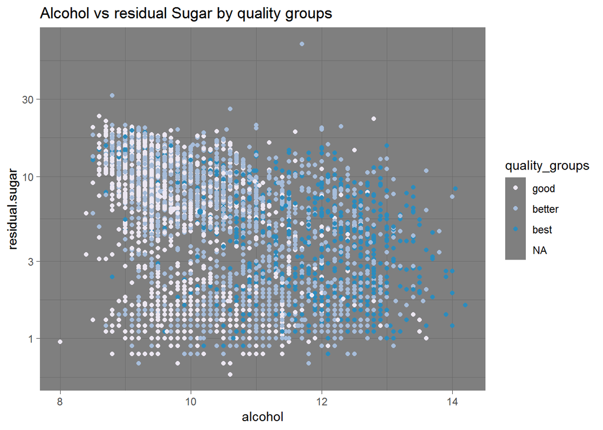

> As mentioned previously, residual sugar did not have a lot of effect on white wine ratings as most of the dots are almost evently distributed in reference to residual sugar but clearly highly rated wines (darker blue dots) were those with higher levels of alcohol % per volume.

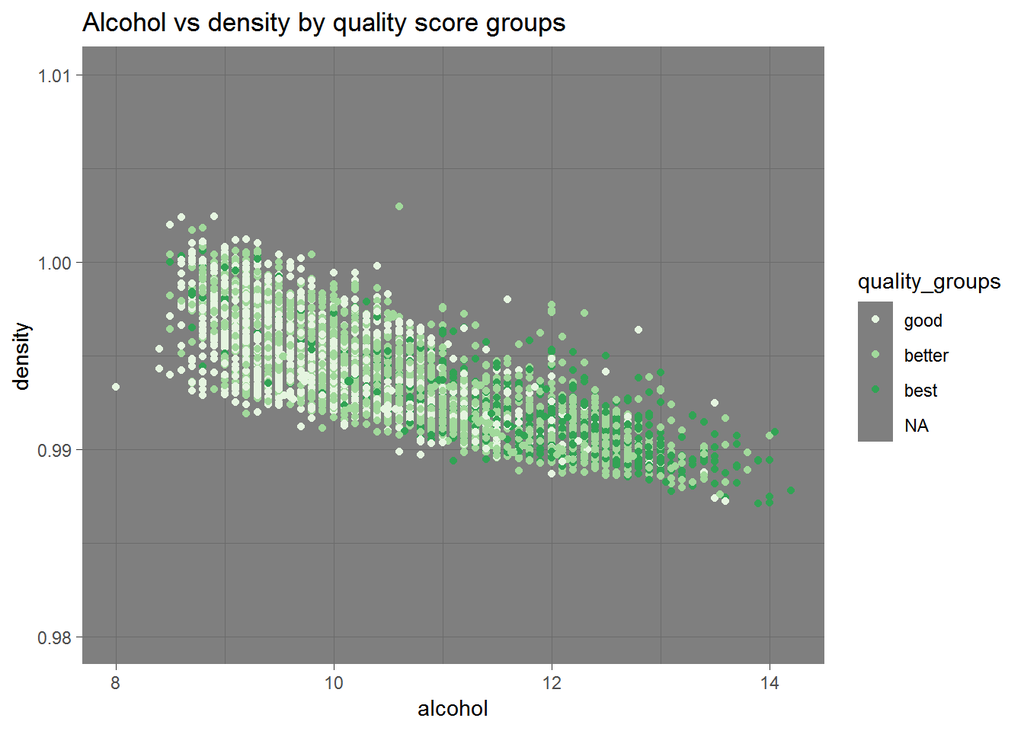

> There is definitely a negative correlation between density and alcohol levels and the quality of white wines.

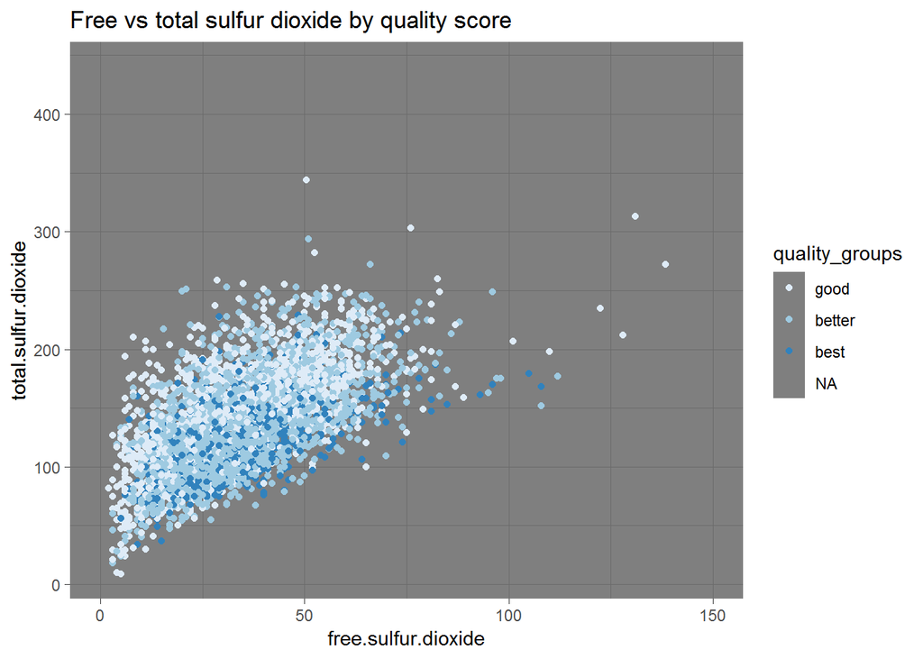

> High wine quality score is correlated to low total sulfur dioxide levels

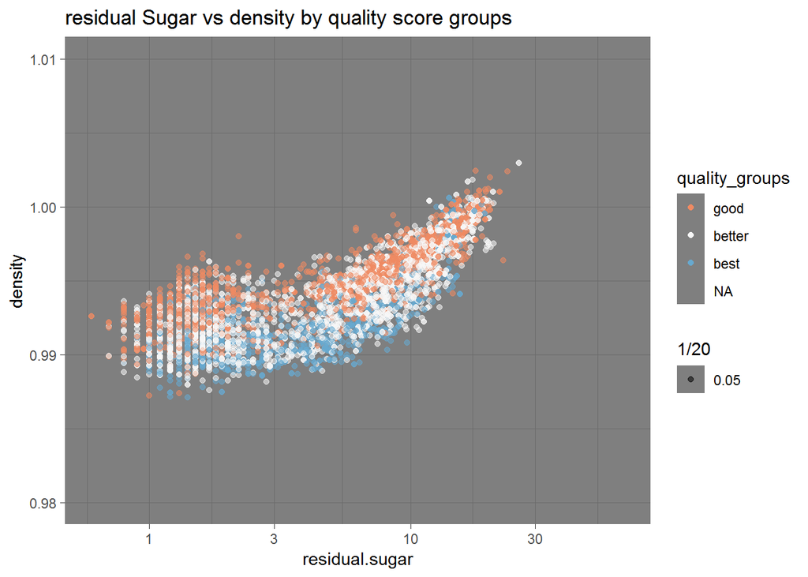

> Beside a few outliers, it seems that highly rated wines had average levels of residual sugars and low density.

```
##
## Calls:
## m1: lm(formula = (quality ~ alcohol), data = wwq)
## m2: lm(formula = quality ~ alcohol + citric.acid, data = wwq)
## m3: lm(formula = quality ~ alcohol + citric.acid + free.sulfur.dioxide,
##     data = wwq)
## m4: lm(formula = quality ~ alcohol + citric.acid + free.sulfur.dioxide +
##     total.sulfur.dioxide, data = wwq)
## m5: lm(formula = quality ~ alcohol + citric.acid + free.sulfur.dioxide +
##     total.sulfur.dioxide + density, data = wwq)
## m6: lm(formula = quality ~ alcohol + citric.acid + free.sulfur.dioxide +
##     total.sulfur.dioxide + density + I(log(residual.sugar)),
##     data = wwq)
##
## ======================================================================================
##                              m1        m2        m3        m4        m5        m6
## --------------------------------------------------------------------------------------
##   (Intercept)                0.582     0.510     0.076     0.413   -24.714    37.096
##
##   alcohol                    0.313     0.315     0.337     0.318     0.359     0.292
##
##   citric.acid                          0.175     0.107     0.135     0.090     0.193
##
##   free.sulfur.dioxide                            0.006     0.009     0.009     0.008
##
##   total.sulfur.dioxide                                    -0.002    -0.002    -0.002
##
##   density                                                           24.914   -36.822
##
##   I(log(residual.sugar))                                                       0.175
##
## --------------------------------------------------------------------------------------
##   R-squared
##   adj. R-squared
##   sigma
##   F
##   p
##   Log-likelihood
##   Deviance                   0.000     0.000     0.000     0.000     0.000     0.000
##   AIC
##   BIC
##   N                       4898      4898      4898      4898      4898      4898
## ======================================================================================
```

# Multivariate Analysis

## Linear Models

### strengths and limitations of the models

# Final Plots and Summary

#### plot 1

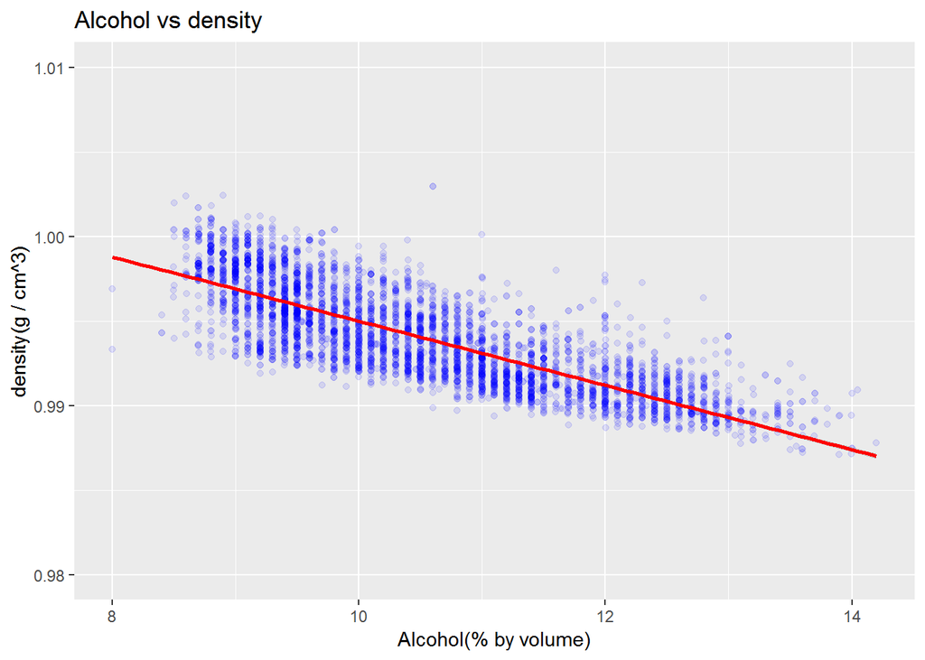

#### plot 2

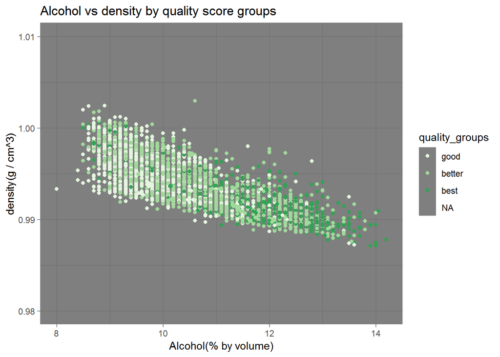

#### Description two

> In the plot above, darker green dots are concentrated on the right lower side of the graph. We can interpret that white wines with low density and high alcohol were rated higher by wine experts and those with high density and low alcohol were rated lower.

#### plot 3

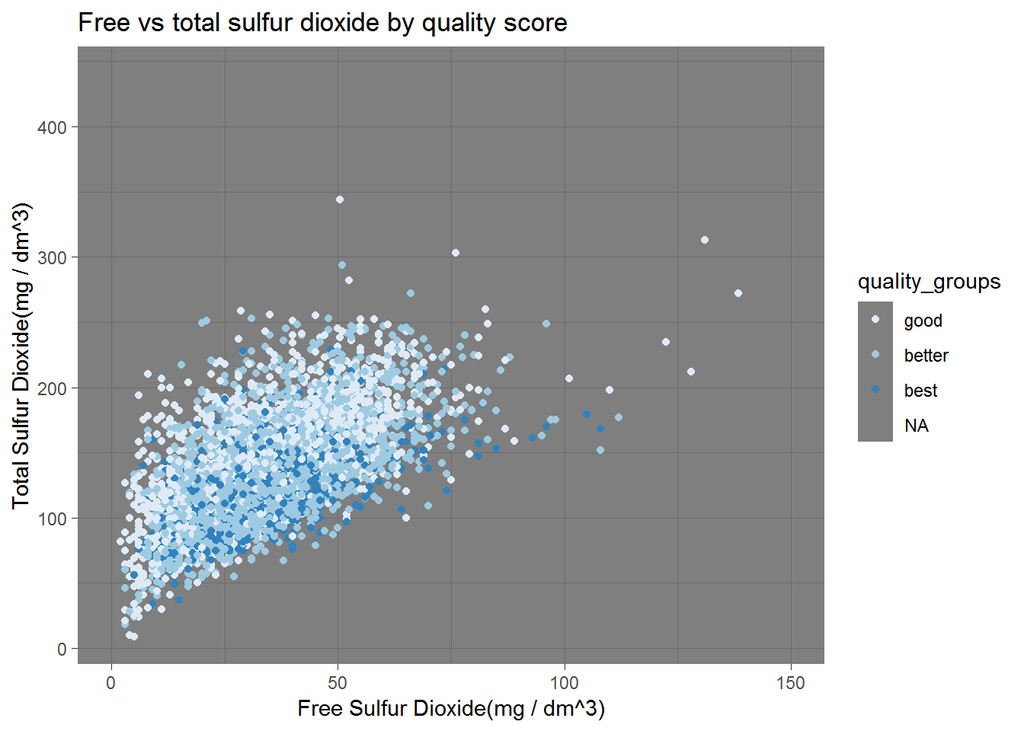

### Description three

> Since free and total sulfur were positively correlated; the more the free sulfur dioxide concentrations, the higher the total sulfur dioxide concentrations as well, using the graph above, highly rated wines had low total sulfur dioxide levels. This does make a lot of practical sense especially since high levels of sulfur dioxide would make wines smell like rotten eggs, so ideally low sulfur dioxide levels are better.

# Reflection

> Difficulties with the analysis arose with selecting the relevant plots for different variables and also with deciding which variables to do a log transformation on and which ones not to.

> From the white wine analysis, I conclude that there isn’t just one characteristic that defines good quality wine, its more of a balance of various physiochemical components.

## References

> 1. USDA, Sulfur dioxide - Technical Evaluation Report. Retrived from https://www.ams.usda.gov/sites/default/files/media/Sulfur%20dioxide%20smoke%20bombs%20report%202011.pdf on 10/13/2018
> 2. Data text, retrived from https://s3.amazonaws.com/udacity-hosted-downloads/ud651/wineQualityInfo.txt